# Assignment 1 - The tidyverse

Adrian Werner

September 24, 2022 | 16:31:04 | CEST

```r
library("tidyverse")
library(legislatoR)
library(lubridate)
```

### Getting started with the Comparative Legislators Database

The Comparative Legislators Database (CLD) includes political, sociodemographic, career, online presence, public attention, and visual information for over 45,000 contemporary and historical politicians from ten countries (see the [corresponding article](https://www.cambridge.org/core/journals/british-journal-of-political-science/article/comparative-legislators-database/D28BB58A8B2C08C8593DB741F42C18B2) for more information). It can be accessed via `legislatoR` - an R package that is available on both [CRAN](https://cran.r-project.org/web/packages/legislatoR/index.html) and [GitHub](https://github.com/saschagobel/legislatoR).

For the following tasks, you will work with ONE of the legislatures. The legislature you’ll work with depends on your first name:

| Your first name starts with… | Legislature | Code |
| --- | --- | --- |
| A-C | Austrian Nationalrat | `aut` |
| D-F | Canadian House of Commons | `can` |
| G-I | Czech Poslanecka Snemovna | `cze` |
| J-L | Spanish Congreso de los Diputados | `esp` |
| M-O | French Assemblée | `fra` |
| P-R | German Bundestag | `deu` |
| S-U | Irish Dail | `irl` |
| V-X | UK House of Commons | `gbr` |
| Y-Z | US House of Representatives | `usa_house` |

The following tasks will be based on data from the `core` and `political` tables of the database.

### Task 1 - Descriptives [8 points in total]

1. What’s the overall share of male legislators in the entire dataset? [1 point]

```r
aut_house_core <- get_core(legislature = "aut")

table(aut_house_core$sex)/length(aut_house_core$sex)
```

```
   female      male
0.1861674 0.8138326
```

2. How many (both in absolute and relative terms) legislators died in the same place they were born in? [1 point]

```r
aut_house_core %>%
  filter(aut_house_core$birthplace == aut_house_core$deathplace) %>%
  nrow()
```

```
[1] 253
```

```r
aut_house_core %>%
  filter(aut_house_core$birthplace == aut_house_core$deathplace) %>%
  nrow()/nrow(aut_house_core)
```

```
[1] 0.1315653
```

3. Create a new variable `age_at_death` that reports the age at which legislators died. Then, plot the distribution of that variable for the entire dataset. [2 points]

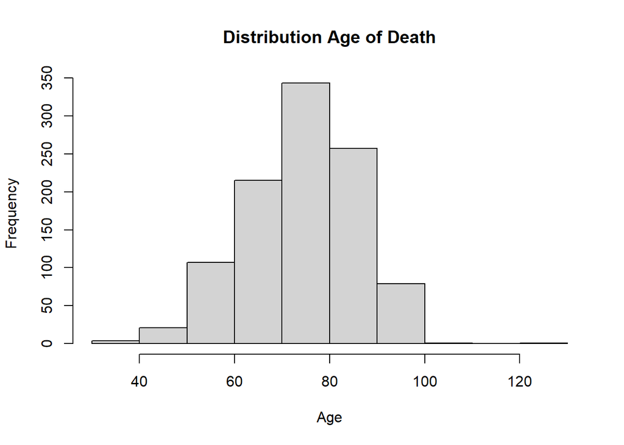

```r
aut_house_core2 <- aut_house_core %>%
  select(name, death, birth) %>%
  mutate(
    age_at_death = time_length(difftime(aut_house_core$death, aut_house_core$birth), "years")
  )

hist(aut_house_core2$age_at_death, main = "Distribution Age of Death", xlab = "Age")
```

4. What is the most frequent birthday in your sample (e.g., “January 15”)? [2 points]

```r
birth_fac <- as.factor(aut_house_core$birth)
names(which.max(table(birth_fac)))
```

```
[1] "1975-05-07"
```

5. Generate a table that provides the 5 legislators with the longest names (in terms of number of characters, ignoring whitespace). [2 points]

```r
aut_house_core3 <- aut_house_core %>%
  select(name) %>%
  mutate(
    character_length = nchar(name))  %>%
  arrange(desc(character_length)
  )

 aut_house_core4 <- head(aut_house_core3, 5)

 aut_house_core4
```

|  | name | character_length |
| --- | --- | --- |
| 698 | Schauer-Schoberlechner Johannes | 31 |
| 4668 | Kaufmann-Bruckberger Elisabeth | 30 |
| 4594 | Cortolezis-Schlager Katharina | 29 |
| 4866 | Holzinger-Vogtenhuber Daniela | 29 |
| 5074 | Hoyos-Trauttmansdorff Douglas | 29 |

### Task 2 - Exploring trends in the data [8 points in total]

1. Using data from all sessions, provide a plot that shows the share of male legislators by session! [3 points]

```r
aut_house_pol <- get_political(legislature = "aut")

merged_df <- merge.data.frame(aut_house_core, aut_house_pol)

merged_df %>%
  mutate(gender = ifelse(merged_df$sex == "male", 1, 0)) %>%
  group_by(session) %>%
    summarise(perc_male = ((sum(gender)/length(gender))))
```

| session | perc_male |
| --- | --- |
| 1 | 0.9405941 |
| 2 | 0.9505495 |
| 3 | 0.9661017 |
| 4 | 0.9447236 |
| 5 | 0.9435028 |
| 6 | 0.9421965 |
| 7 | 0.9382022 |
| 8 | 0.9444444 |
| 9 | 0.9385475 |
| 10 | 0.9395604 |

[output cut: 17 more lines]

2. Explore another relation of variables in the dataset. Your analysis should (i) use data from both the `core` and the `political` table and (ii) feature data from several sessions. Also, offer a brief description and interpretation of your findings! [5 points]

```r
merged_df %>%
  mutate(death_no = ifelse(is.na(merged_df$death), 0, 1)) %>%
  group_by(party) %>%
    summarise(death_no = sum(death_no)/length(death_no)) %>%
  arrange(desc(death_no))
```

| party | death_no |
| --- | --- |
| CsP | 1.00000000 |
| GdP | 1.00000000 |
| HB | 1.00000000 |
| KPÖ | 1.00000000 |
| LBd | 1.00000000 |
| NWB | 1.00000000 |
| SdP | 1.00000000 |
| VO | 1.00000000 |
| WdU | 1.00000000 |
| none | 0.81818182 |

[output cut: 9 more lines]